# Talk slides

## Turning

[figure not shown]

## into

[figure not shown]

### Nicole Carlson @parsing_science github.com/parsing-science

## Overview

- Motivating Example: Scikitlearn Linear Regression
- Intro to PyMC3
- PyMC3 Linear Regression
- Compare Scikitlearn and PyMC3
- Implement Hiearchical Logistic Regression in PyMC3
- Use the Hierarchical Logistic Regression

## Motivating Example: Scikitlearn

## Generate Fake Data

```python
X = np.random.randn(1000, 1)
noise = 2 * np.random.randn(1000, 1)
Y = 4 * X + 3 + noise
```

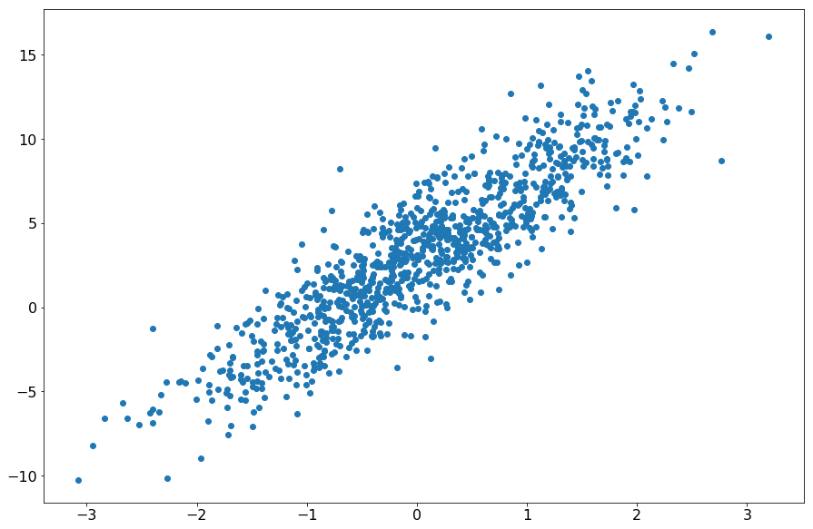

```python
plt.scatter(X, Y)
```

## Create a LinearRegression instance and use it

```python
LR = LinearRegression()
```

```python
LR.fit(X, Y)
```

```
LinearRegression(copy_X=True, fit_intercept=True, n_jobs=1, normalize=False)
```

```python
X_predict = LR.predict(X)
```

```python
LR.score(X, Y)
```

```
0.80613292900134936
```

## Save and Load LR

```python
pickle.dump(LR, open('LR.pickle', 'wb'))
```

```python
saved_LR = pickle.load(open('LR.pickle', 'rb'))
```

```python
saved_LR.score(X, Y)
```

```
0.80613292900134936
```

## Intro to PyMC3

- Library for Probabilistic Modeling
- MCMC Samplers
- Variational Fitting Algorithms
- Built on top of Theano
- Completely written in Python

## Using PyMC3

- Step 1: Set up: Parameterize your model, choose priors, and insert training data
- Step 2: Inference: infer your parameters using sampling (e.g. NUTS) or variational inference (e.g. ADVI)
- Step 3: Interpret: Check your parameter distributions and model fit
- Step 4: Predict data: Create posterior samples with your inferred parameters

## Step 1: Set up the PyMC3 model

```python
lin_reg_model = pm.Model()
with lin_reg_model:

    alpha = pm.Normal('alpha', mu=0, tau=10.**-2, shape=(1))
    betas = pm.Normal('betas', mu=0, tau=10. ** -2, shape=(1))

    s = pm.HalfNormal('s', tau=1)

    temp = alpha + betas * X

    y = pm.Normal('y', mu=temp , tau=s ** -2, observed=Y)
```

## Step 2: Infer your parameters

```python
with lin_reg_model:
    step = pm.NUTS()
    nuts_trace = pm.sample(2e3, step)
```

## Step 3: Interpret your parameters

```python
summary(nuts_trace)
```

```
alpha:

  Mean             SD               MC Error         95% HPD interval
  -------------------------------------------------------------------

  2.993            0.280            0.022            [2.886, 3.143]

  Posterior quantiles:
  2.5            25             50             75             97.5
  |--------------|==============|==============|--------------|

  2.879          2.971          3.015          3.055          3.140


betas:

  Mean             SD               MC Error         95% HPD interval
  -------------------------------------------------------------------

  3.973            0.390            0.032            [3.873, 4.123]

  Posterior quantiles:
  2.5            25             50             75             97.5
  |--------------|==============|==============|--------------|

  3.877          3.960          4.005          4.048          4.129


s:

  Mean             SD               MC Error         95% HPD interval
  -------------------------------------------------------------------

  2.021            0.698            0.045            [1.876, 2.073]

  Posterior quantiles:
  2.5            25             50             75             97.5
  |--------------|==============|==============|--------------|

  1.888          1.940          1.972          2.001          2.095
```

```
array([[<matplotlib.axes._subplots.AxesSubplot object at 0x10e60b050>,
        <matplotlib.axes._subplots.AxesSubplot object at 0x10e859090>]], dtype=object)
```

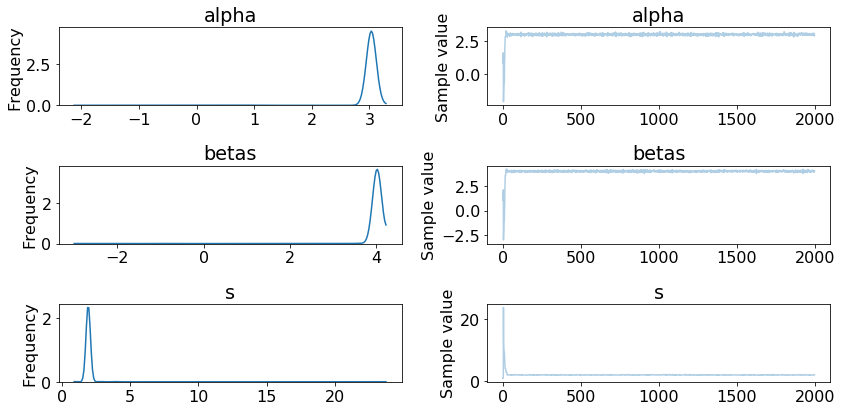

```python
traceplot(nuts_trace)
```

## Step 4: Predict data by creating posterior predictive samples

```python
ppc = pm.sample_ppc(
    nuts_trace[1000:],
    model=lin_reg_model,
    samples=1000
)
```

```python
pred = ppc['y'].mean(axis=0)
```

```python
r2_score(Y, pred)
```

```
0.80553921760805347
```

## Most PyMC3 Examples

- Exist in Jupyter notebooks
- Focus on training a model with one dataset
- Don’t demonstrate how to predict new data
- Don’t show how to save your model for later use

## Comparing the two libraries

|  | sklearn | PyMC3 |
| --- | --- | --- |
| Find model parameters | Easy | Medium |
| Predict new data | Easy | Difficult |
| Score a model | Easy | Difficult |
| Save a trained model | Easy | Impossible? |
| Load a trained model | Easy | Impossible? |

## What we want to reproduce in PyMC3

- fit
- predict
- score
- save
- load

## Map between Scikitlearn and PyMC3

| sklearn | PyMC3 |
| --- | --- |
| Fit | Step 1: Set up, Step 2: Inference |
| Predict | Step 4: Predict data |
| Score | Step 4: Predict data |
| Save/Load | ?? |
| ?? | Step 3: Interpret |

## Initializing the HLM class

```python
class HLM(BaseEstimator):
    """
    Custom Hierachical Linear Model built using PyMC3.
    """

    def __init__(self):
        self.cached_model = None
        self.shared_vars = None
        self.num_cats = None
        self.num_pred = None
        self.advi_trace = None
        self.v_params = None
```

## Fit

```python
def fit(self, X, cats, y):
    """
    Train the HLM model

    Parameters
    ----------
    X : numpy array, shape [n_samples, n_features]

    cats: numpy array, shape [n_samples, ]

    y : numpy array, shape [n_samples, ]
    """
    self.num_cats = len(np.unique(cats))
    num_samples, self.num_pred = X.shape

    if self.cached_model is None:
        # Step 1: Set up the model
        self.cached_model, o = self.create_model()

    #Step 2: Inference
    minibatch_tensors = [
        self.shared_vars['model_input'],
        self.shared_vars['model_output'],
        self.shared_vars['model_cats']
    ]
    minibatch_RVs = [o]

    minibatches = self._create_minibatch([X, y, cats], num_samples)

    self.v_params, self.advi_trace = self._inference(
        minibatch_tensors,
        minibatch_RVs,
        minibatches,
        num_samples
    )

    return self
```

## Step 1: Set up the model

```python
def create_model(self):
    """
    Creates and returns the PyMC3 model.

    Returns the model and the output variable. The latter is for use in ADVI minibatch.
    """
    model_input = theano.shared(np.zeros([1, self.num_pred]))

    model_output = theano.shared(np.zeros(1))

    model_cats = theano.shared(np.zeros(1, dtype='int'))

    self.shared_vars = {
        'model_input': model_input,
        'model_output': model_output,
        'model_cats': model_cats
    }

    model = pm.Model()

    with model:
        # Both alpha and beta are drawn from Normal distributions
        mu_alpha = pm.Normal("mu_alpha", mu=0, sd=10)
        sigma_alpha = pm.HalfNormal("sigma_alpha", sd=10)

        mu_beta = pm.Normal("mu_beta", mu=0, sd=10)
        sigma_beta = pm.HalfNormal("sigma_beta", sd=10)

        alpha = pm.Normal(
            'alpha',
            mu=mu_alpha,
            sd=sigma_alpha,
            shape=(self.num_cats,)
        )

        beta = pm.Normal(
            'beta',
            mu=mu_beta,
            sd=sigma_beta,
            shape=(self.num_cats, self.num_pred)
        )

        c = model_cats

        temp = alpha[c] + T.sum(beta[c] * model_input, 1)

        p = pm.invlogit(temp)

        o = pm.Bernoulli('o', p, observed=model_output)

    return model, o
```

## Step 2a: Inference: Create minibatches for ADVI

```python
@staticmethod
def _create_minibatch(data, num_samples, size=100):
    """
    Generator that returns mini-batches in each iteration
    """
    while True:
        # Return random data samples of set size each iteration
        ixs = np.random.randint(num_samples, size=size)
        yield [tensor[ixs] for tensor in data]
```

## Step 2: Inference

```python
def _inference(
    self,
    minibatch_tensors,
    minibatch_RVs,
    minibatches,
    num_samples
):
    """
    Runs minibatch variational ADVI and then sample from those results.
    """
    with self.cached_model:
        v_params = pm.variational.advi_minibatch(
            n=50000,
            minibatch_tensors=minibatch_tensors,
            minibatch_RVs=minibatch_RVs,
            minibatches=minibatches,
            total_size=int(num_samples),
            learning_rate=1e-2,
            epsilon=1.0
        )

        advi_trace = pm.variational.sample_vp(v_params, draws=7500)

    return v_params, advi_trace
```

## Predict Probabilities

```python
def predict_proba(self, X, cats):
    """
    Predicts probabilities of new data with a trained HLM

    Parameters
    ----------
    X : numpy array, shape [n_samples, n_features]

    cats: numpy array, shape [n_samples, ]
    """

    if self.advi_trace is None:
        raise PSToolkitError("Run fit on the model before predict.")

    num_samples = X.shape[0]

    if self.cached_model is None:
        self.cached_model, o = self.create_model()

    # Step 4: Predict data
    self._set_shared_vars(X, np.zeros(num_samples), cats)

    ppc = pm.sample_ppc(
        self.advi_trace,
        model=self.cached_model,
        samples=2000
    )

    return ppc['o'].mean(axis=0)
```

## Set Shared Variables (part of Step 4)

```python
def _set_shared_vars(self, model_input, model_output, model_cats):
    """
    Creates theano shared variables for the PyMC3 model.
    """
    self.shared_vars['model_input'].set_value(model_input)

    self.shared_vars['model_output'].set_value(model_output)

    self.shared_vars['model_cats'].set_value(model_cats)
```

## Predict

```python
def predict(self, X, cats):
    """
    Predicts labels of new data with a trained HLM

    Parameters
    ----------
    X : numpy array, shape [n_samples, n_features]

    cats: numpy array, shape [n_samples, ]
    """
    ppc_mean = self.predict_proba(X, cats)

    pred = ppc_mean > 0.5

    return pred
```

## Score

```python
def score(self, X, cats, y):
    """
    Scores new data with a trained model.

    Parameters
    ----------
    X : numpy array, shape [n_samples, n_features]

    cats: numpy array, shape [n_samples, ]

    y : numpy array, shape [n_samples, ]
    """
    return accuracy_score(y, self.predict(X, cats))
```

## Save

```python
def save(self, file_prefix):
    """
    Saves the advi_trace, v_params, and param files with the given file_prefix.

    Parameters
    ----------
    file_prefix: str
    path and prefix used to identify where to save trace and params for this model.
    ex. given file_prefix = "path/to/file/"
    This will attempt to save to "path/to/file/advi_trace.pickle" and "path/to/file/params.pickle"
    """
    fileObject = open(file_prefix + "advi_trace.pickle", 'w')
    joblib.dump(self.advi_trace, fileObject)
    fileObject.close()

    fileObject = open(file_prefix + "v_params.pickle", 'w')
    joblib.dump(self.v_params, fileObject)
    fileObject.close()

    fileObject = open(file_prefix + "params.pickle", 'w')
    joblib.dump(
        {"num_cats": self.num_cats, "num_pred": self.num_pred},
        fileObject
    )
    fileObject.close()
```

## Load

```python
def load(self, file_prefix):
    """
    Loads a saved version of the advi_trace, v_params, and param files with the given file_prefix.

    Parameters
    ----------
    file_prefix: str
    path and prefix used to identify where to load saved trace and params for this model.
    ex. given file_prefix = "path/to/file/"
    This will attempt to load "path/to/file/advi_trace.pickle" and "path/to/file/params.pickle"
    """
    self.advi_trace = joblib.load(file_prefix + "advi_trace.pickle")
    self.v_params = joblib.load(file_prefix + "v_params.pickle")

    params = joblib.load(file_prefix + "params.pickle")
    self.num_cats = params["num_cats"]
    self.num_pred = params["num_pred"]
```

## Use the Custom PyMC3 Class

## Generate Fake Data

```python
num_pred = 2
num_samples = 50000
num_categories = 2
```

```python
alphas = 5 * np.random.randn(num_categories) + 5 # mu_alpha = sigma_alpha = 5
betas = 10 * np.random.randn(num_categories, num_pred) + 10 # mu_beta = sigma_beta = 10
```

```python
alphas
```

```
array([ 1.15856219,  4.02812109])
```

```python
betas
```

```
array([[  7.49863681,   9.0573482 ],
       [ -2.53113336,  23.23233084]])
```

```python
def numpy_invlogit(x):
    return 1 / (1 + np.exp(-x))
```

```python
x_a = np.random.randn(num_samples, num_pred)
y_a = np.random.binomial(1, numpy_invlogit(alphas[0] + np.sum(betas[0] * x_a, 1)))
x_b = np.random.randn(num_samples, num_pred)
y_b = np.random.binomial(1, numpy_invlogit(alphas[1] + np.sum(betas[1] * x_b, 1)))

X = np.concatenate([x_a, x_b])
Y = np.concatenate([y_a, y_b])
cats = np.concatenate([
    np.zeros(num_samples, dtype=np.int),
    np.ones(num_samples, dtype=np.int)
])
```

## Load the class

```python
from ps_toolkit import HLM
```

```python
HLM1 = HLM()
```

## Fit the HLM

```python
HLM1.fit(X, cats, Y)
```

```
Finished minibatch ADVI: ELBO = -10,423.93
```

```
HLM()
```

## Predict and score the model

```python
probs = HLM1.predict_proba(X, cats)
```

```python
pred = HLM1.predict(X, cats)
```

```python
HLM1.score(X, cats, Y)
```

```
0.96577999999999997
```

## Save and Load the model

```python
HLM1.save("HLM_jar/")
```

```python
HLM2 = HLM()
```

```python
HLM2.load("HLM_jar/")
```

```python
HLM2.score(X, cats, Y)
```

```
0.96589999999999998
```

## Step 3: Interpret your parameters

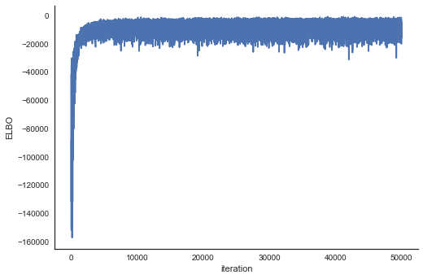

```python
HLM1.plot_elbo()
```

```python
summary(HLM1.advi_trace)
```

```
mu_alpha:

  Mean             SD               MC Error         95% HPD interval
  -------------------------------------------------------------------

  2.707            2.681            0.033            [-2.503, 7.875]

  Posterior quantiles:
  2.5            25             50             75             97.5
  |--------------|==============|==============|--------------|

  -2.479         0.924          2.682          4.527          7.913


mu_beta:

  Mean             SD               MC Error         95% HPD interval
  -------------------------------------------------------------------

  7.489            4.976            0.057            [-2.638, 16.969]

  Posterior quantiles:
  2.5            25             50             75             97.5
  |--------------|==============|==============|--------------|

  -2.346         4.162          7.456          10.849         17.359


alpha:

  Mean             SD               MC Error         95% HPD interval
  -------------------------------------------------------------------

  1.199            0.027            0.000            [1.147, 1.251]
  4.200            0.051            0.001            [4.102, 4.301]

  Posterior quantiles:
  2.5            25             50             75             97.5
  |--------------|==============|==============|--------------|

```

[output cut: 37 more lines]

```
  1.429          3.129          4.595          6.851          14.727


sigma_beta:

  Mean             SD               MC Error         95% HPD interval
  -------------------------------------------------------------------

  11.615           3.869            0.043            [5.141, 19.352]

  Posterior quantiles:
  2.5            25             50             75             97.5
  |--------------|==============|==============|--------------|

  5.837          8.900          11.023         13.642         20.937
```

```python
alphas
```

```
array([ 1.15856219,  4.02812109])
```

```python
betas
```

```
array([[  7.49863681,   9.0573482 ],
       [ -2.53113336,  23.23233084]])
```

```
array([[<matplotlib.axes._subplots.AxesSubplot object at 0x103410050>,
        <matplotlib.axes._subplots.AxesSubplot object at 0x13f1e56d0>]], dtype=object)
```

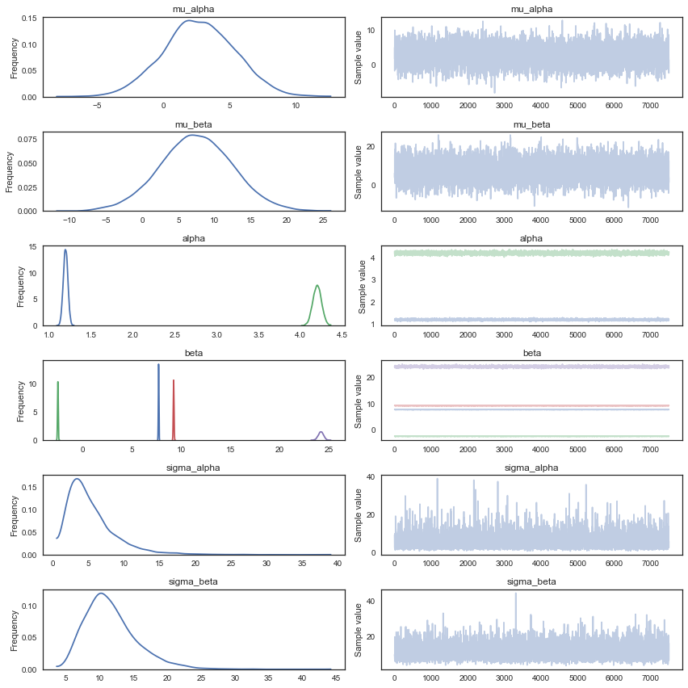

```python
traceplot(HLM1.advi_trace)
```

## Next Steps

- Build Bayesian Model base class
- Pass more options to the init function
- Test if this class can be used in an sklearn pipeline

## Thanks:

- Daniel Little
- Tudor Radoaca
- Nico Sandller
- PyData Chicago

### @parsing_science github.com/parsing-science